# Statistical Rethinking Problems: Chapter 4

Simon Thornewill von Essen

2024-03-26

## 4e1

In the model definition below, which line is the likelihood?

$$y_i \sim \textrm{N}(\mu, \sigma) \\
\mu \sim \textrm{N}(0, 10) \\
\sigma \sim \textrm{Exp}(1)$$

The first line is the likelihood function, the other two are priors.

## 4e2

In the model definition from the last question, how many parameters are in the posterior distribution?

Because there are only two priors and nothing defining shape of both priors having more than 1 value, there are only two dimensions in the posterior.

## 4e3

Using the same model definition as the last question, write down the appropriate form of Bayes’ theorem that includes the proper likelihood and priors.

$$P(\mu, \sigma | y_i) = \frac{P(y_i |
\mu, \sigma)P(\mu)P(\sigma)}
{\int \int P(y_i | \mu, \sigma)P(\mu)P(\sigma) d\mu
d\sigma}$$

Since we have multiple data points…

$$P(\mu, \sigma | y_i) = \frac{\prod_i
[P(y_i | \mu, \sigma)]P(\mu)P(\sigma)}
{\int \int \prod_i [P(y_i | \mu, \sigma)]P(\mu)P(\sigma) d\mu
d\sigma}$$

## 4E4

In the model definition below, which line is the linear model?

$$y_i \sim \textrm{N}(\mu_i, \sigma) \\
\mu_i = \alpha + \beta x_i \\
\alpha \sim \textrm{N}(0, 10) \\
\beta \sim \textrm{N}(0, 1) \\
\sigma \sim \textrm{Exp}(2)$$

The second line is the linear model.

## 4E5

How many parameters are there in the posterior distribution?

There are 3 and not 4 parameters. The 2nd line doesn’t count as a parameter although in most PPLs you can still treat it as such.

I.e. Variables which are deterministic combinations and not stochastic relationships between priors are not “parameters”, or rather “unobserved variables”.

## 4M1

Perform a prior predictive check for the model below

$$y_i \sim \textrm{N}(\mu, \sigma) \\
\mu \sim \textrm{N}(0, 10) \\
\sigma \sim \textrm{Exp}(1)$$

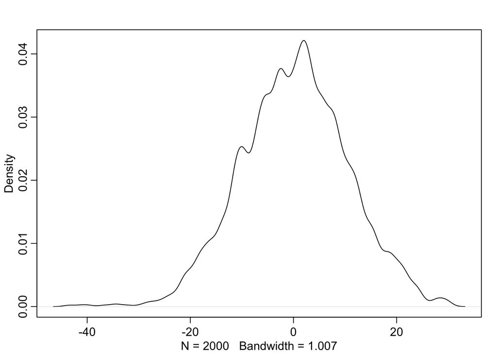

```r
sigma = rexp(n = 2000, rate = 1)
mu = rnorm(n = 2000, mean = 0, sd = 10)

yi = rnorm(n = 2000, mean = mu, sd = sigma)

dens(yi)
```

## 4M2

Translate this model into a `quap` formula.

```
ch4.m2 = quap(
  alist(
    y ~ dnorm(mu, sigma),
    mu ~ dnorm(0, 10),
    sigma ~ dexp(1)
  )
)
```

That’s easy enough but its a shame that `quap` doesn’t seem to support prior predictive checks?

## 4M3

Translate the `quap` formula below into a mathematical formula.

```
y ~ dnorm( mu, sigma),
mu <- a + b*x,
a ~ dnorm( 0, 10),
b ~ dunif( 0, 1),
sigma ~ dexp( 1)
```

$$y_i \sim \textrm{N}(\mu, \sigma) \\
mu = a + bx_i \\
a \sim \textrm{N}(0, 10) \\
b \sim \textrm{Uniform}(0, 1) \\
\sigma \sim \textrm{Exp}(1)$$

## 4M4

A sample of students is measured for height each year for 3 years. After the third year, you want to fit a linear regression predicting height using year as a predictor. Write down the mathematical model definition for this regression, using any variable names and priors you choose. Be prepared to defend your choice of priors.

$$height_i \sim \textrm{N}(\mu, \sigma)
\\
\mu = a + bx_i \\
a \sim \textrm{N}(175, 5) \\
b \sim \textrm{Exp}(1) \\
\sigma \sim \textrm{Exp}(1)$$

I expect that height will be normally distributed with nosie sigma, which I expect is exponentially distributed with a rate of 1, just a general prior.

The mean is a sum of the initial measurement alpha plus some amount per year beta. I make beta exponentially distributed because I expect that students can’t shrink over the course of 3 years.

For alpha, 175cm +/- ~10cm sounds like a good general height for a student near adulthood to be.

## 4M5

Now suppose I remind you that every student got taller each year. Does this information lead you to change your choice of priors? How?

No, because I already took this into account, I’d need to do a prior predictive check to see if I incorporated that inforation correctly though.

## 4M6

Now suppose I tell you that the variance among heights for students of the same age is never more than 64cm. How does this lead you to revise your priors?

I might truncate the exponential to never be more than 64 but luckily if I have an exponential with a rate of 1 then the probability of 64 is already really low so I have negligible probability density over there anyway. The model should be able to funciton as is.

## 4M7

Refit model m4.3 from the chapter, but omit the mean weight xbar this time. Compare the new model’s posterior to that of the original model. In particular, look at the covariance among the parameters. What is different? Then compare the posterior predictions of both models.

```r
data(Howell1); d <- Howell1; d2 <- d[ d$age >= 18,]
xbar <- mean(d2$weight)

# Original
m4.3 <- quap(
  alist(height ~ dnorm( mu, sigma),
        mu <- a + b*( weight - xbar),
        a ~ dnorm( 178, 20),
        b ~ dlnorm( 0, 1),
        sigma ~ dunif( 0, 50)  ), data=d2)

# Without Mean
m4.3_4M6 <- quap(
  alist(height ~ dnorm(mu, sigma),
        mu <- a,
        a ~ dnorm( 178, 20),
        sigma ~ dunif( 0, 50)  ), data=d2)

# List of Rethinking Functions
# - precis
# - vcov
# - extract.samples
# - link
# - sim
```

Alright, now we want to check the vcov of both models

```r
vcov(m4.3)
```

```
##                   a             b         sigma
## a      7.306650e-02 -4.242335e-08  6.156660e-05
## b     -4.242335e-08  1.757597e-03 -2.518742e-05
## sigma  6.156660e-05 -2.518742e-05  3.654049e-02
```

```r
vcov(m4.3_4M6)
```

```
##                 a       sigma
## a     0.169737111 0.000217512
## sigma 0.000217512 0.084902695
```

It’s not quite clear what to make of this right away… I suppose that the variance of `a` and `sigma` is much bigger because the model doesn’t have as much flexibility to model the change in heights over time.

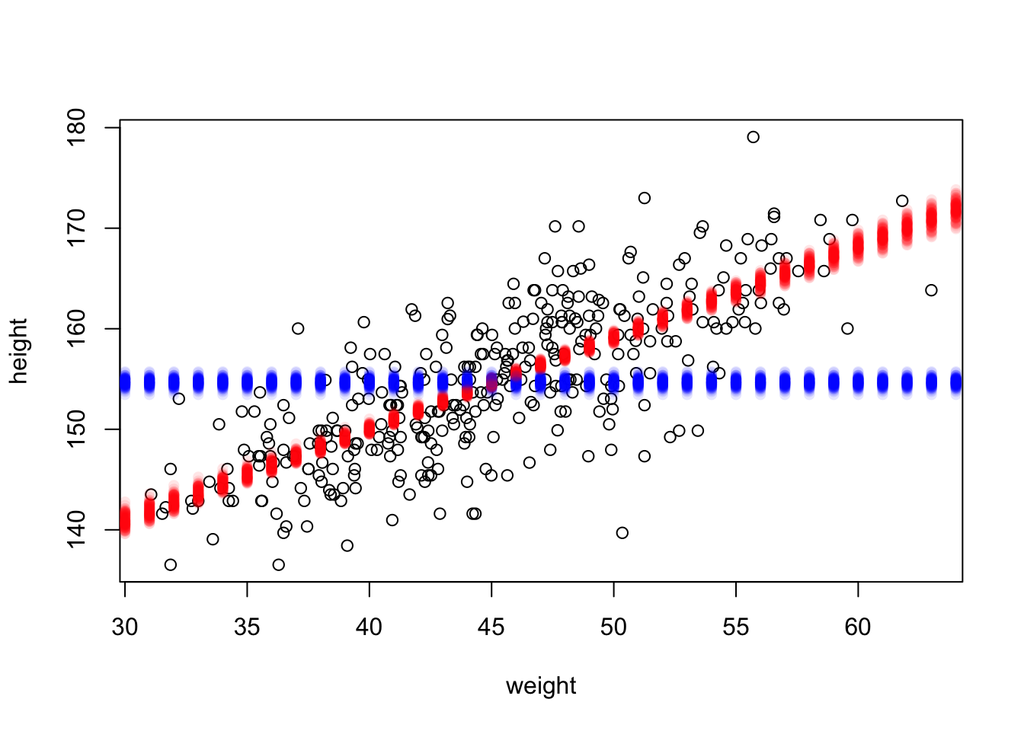

```r
weight.seq <- seq( from=25, to=70, by=1)

sim.m4.3 = link(m4.3, data = data.frame(weight=weight.seq))
sim.m4.3_4M6 = link(m4.3_4M6, data.frame(weight=weight.seq))

plot( height ~ weight, d2)
for (i in 1:100){
  points( weight.seq, sim.m4.3[i,], pch=16, col=col.alpha('red', 0.1))
  points( weight.seq, sim.m4.3_4M6[i,], pch=16, col=col.alpha('blue', 0.1))
}
```

It’s exactly like I thought above…

# 4M8

In the chapter, we used 15 knots with the cherry blossom spline. Increase the number of knots and observe what happens to the resulting spline. Then adjust also the width of the prior on the weights—change the standard deviation of the prior and watch what happens. What do you think the combination of knot number and the prior on the weights controls?

```r
data("cherry_blossoms")
d.cherry = cherry_blossoms
d2.cherry = d.cherry[complete.cases(d.cherry$doy), ]

num_knots = 20
knot_list = quantile(d2.cherry$year, probs=seq(0, 1, length.out=num_knots))

B = bs(d2.cherry$year, knots=knot_list[-c(1, num_knots)],
       degree = 3,
       intercept = TRUE)

m4.7 <- quap(
  alist(
    D ~ dnorm(mu, sigma),
    mu <- a + B %*% w,
    a ~ dnorm(100, 10),
    w ~ dnorm(0, 10),
    sigma ~ dexp(1)
  ),
  data=list(D=d2.cherry$doy, B=B),
  start=list(w=rep(0, ncol(B)))
)
```

```
## Caution, model may not have converged.
```

```
## Code 1: Maximum iterations reached.
```

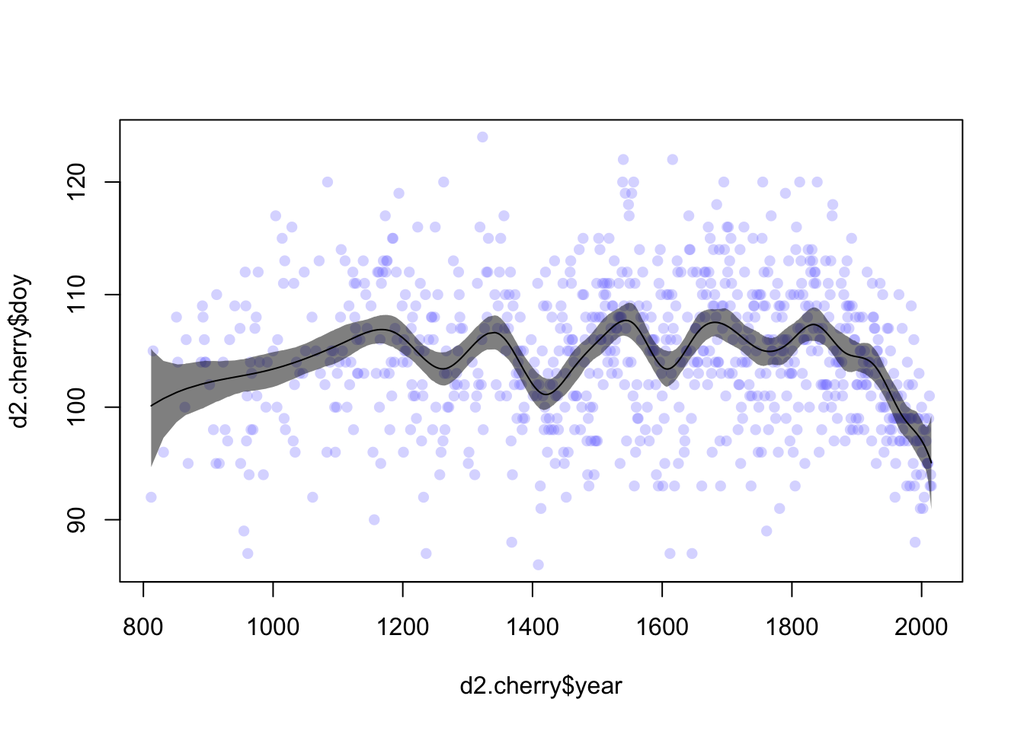

```r
mu = link(m4.7)
mu_PI = apply(mu, 2, PI, prob = 0.89)
mu_mean = apply(mu, 2, mean)

plot(d2.cherry$year, d2.cherry$doy, col=col.alpha(rangi2, 0.3), pch=16)
shade(mu_PI, d2.cherry$year, col=col.alpha('black', 0.5))
lines(d2.cherry$year, mu_mean)
```

By increasing the number of knots we can see that it becomes more flexible allowing it to fit more subtleties in the data, it looks like it may be getting better at finding yearly trends.

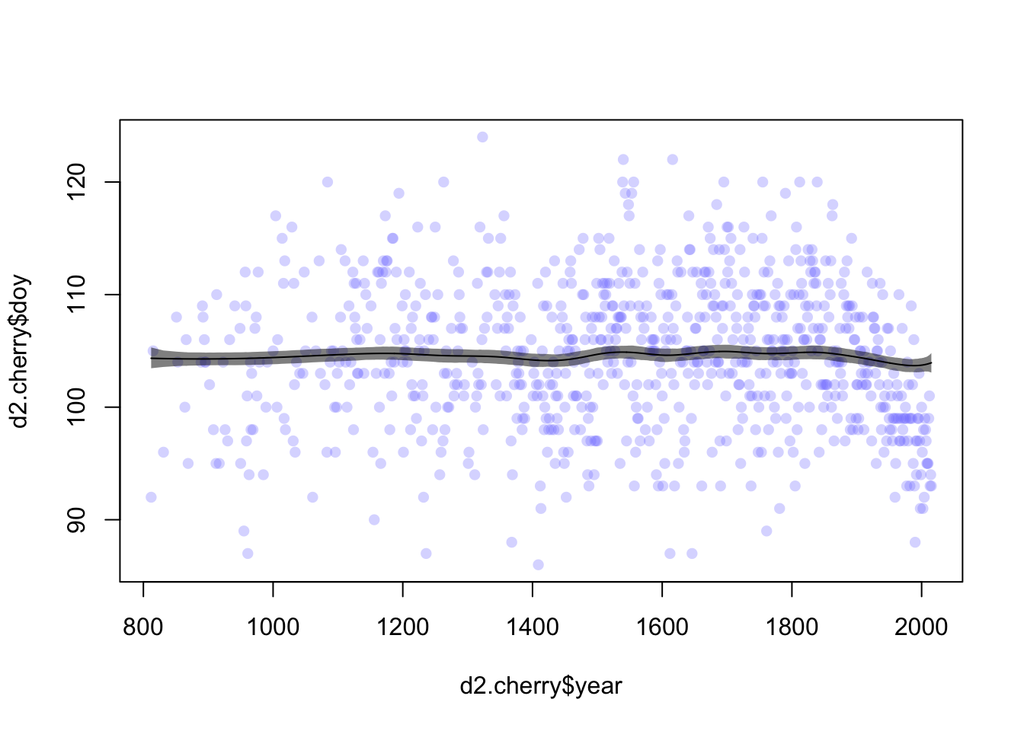

```r
m4.7 <- quap(
  alist(
    D ~ dnorm(mu, sigma),
    mu <- a + B %*% w,
    a ~ dnorm(100, 10),
    w ~ dnorm(0, 0.5),
    sigma ~ dexp(1)
  ),
  data=list(D=d2.cherry$doy, B=B),
  start=list(w=rep(0, ncol(B)))
)

mu = link(m4.7)
mu_PI = apply(mu, 2, PI, prob = 0.89)
mu_mean = apply(mu, 2, mean)

plot(d2.cherry$year, d2.cherry$doy, col=col.alpha(rangi2, 0.3), pch=16)
shade(mu_PI, d2.cherry$year, col=col.alpha('black', 0.5))
lines(d2.cherry$year, mu_mean)
```

The standard deviation on the weights determines how flat the prior is. The flatter it is the more it relies on the information given to us by the data and the stricter it is surrounding 0 the more data it takes to convince us that the value of the weight is not 0.

# 4H1

The weights listed below were recorded in the !Kung census, but heights were not recorded for these individuals. Provide predicted heights and 89% intervals for each of these individuals. That is, fill in the table below, using model-based predictions.

```r
kung = data.frame(
  individual = seq(1, 5),
  weight = c(46.95, 43.73, 64.78, 32.59, 54.63)
)

head(kung)
```

```
##   individual weight
## 1          1  46.95
## 2          2  43.73
## 3          3  64.78
## 4          4  32.59
## 5          5  54.63
```

Right, so what this means is that we want to predict the height using the weights from the model.

```r
kung.samples = link(m4.3, data = kung)

kung.mu = apply(kung.samples, 2, mean)
kung.PI = apply(kung.samples, 2, PI, prob=0.89)

kung$expect_height = kung.mu
kung$interval_height_lower = kung.PI[1, ]
kung$interval_height_upper = kung.PI[2, ]

head(kung)
```

```
##   individual weight expect_height interval_height_lower interval_height_upper
## 1          1  46.95      156.3593              155.9033              156.7998
## 2          2  43.73      153.4461              153.0036              153.8812
## 3          3  64.78      172.4902              171.2221              173.8458
## 4          4  32.59      143.3676              142.4777              144.2588
## 5          5  54.63      163.3074              162.5877              164.0366
```

## 4h2

Select out all the rows in the Howell1 data with ages below 18 years of age. If you do it right, you should end up with a new data frame with 192 rows in it.

1. Fit a linear regression to these data, using `quap`. Present and interpret the estimates. For every 10 units of increase in weight, how much taller does the model predict a child gets?
2. Plot the raw data, with height on the vertical axis and weight on the horizontal axis. Superimpose the MAP regression line and 89% interval for the mean. Also superimpose the 89% interval for predicted heights.
3. What aspects of the model fit concern you? Describe the kinds of assumptions you would change, if any, to improve the model. You don’t have to write any new code. Just explain what the model appears to be doing a bad job of, and what you hypothesize would be a better model.

```r
d3 <- Howell1[ Howell1$age < 18,]
d3.xbar <- mean(d3$weight)

nrow(d3)
```

```
## [1] 192
```

```r
head(d3)
```

```
##    height   weight  age male
## 19 121.92 19.61785 12.0    1
## 20 105.41 13.94795  8.0    0
## 21  86.36 10.48931  6.5    0
## 24 129.54 23.58678 13.0    1
## 25 109.22 15.98912  7.0    0
## 29 137.16 27.32892 17.0    1
```

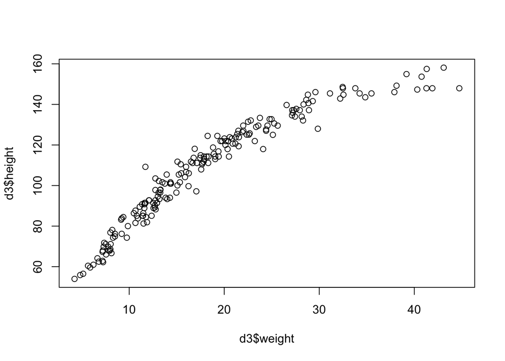

```r
plot(d3$weight, d3$height)
```

Right, so now I need to fit a regression to this…

```r
d3.model = quap(
  alist(
    height ~ dnorm(mu, sigma),
    mu <- a + b*weight,
    a ~ dnorm(60, 2.5),
    b ~ dnorm(40, 10),
    sigma ~ dexp(0.01) # Careful, this sometimes doesn't converge
  ),
  data=d3
)

precis(d3.model)
```

```
##            mean         sd      5.5%     94.5%
## a     58.627470 1.22000603 56.677664 60.577275
## b      2.702955 0.06136878  2.604875  2.801034
## sigma  8.436939 0.43053543  7.748860  9.125018
```

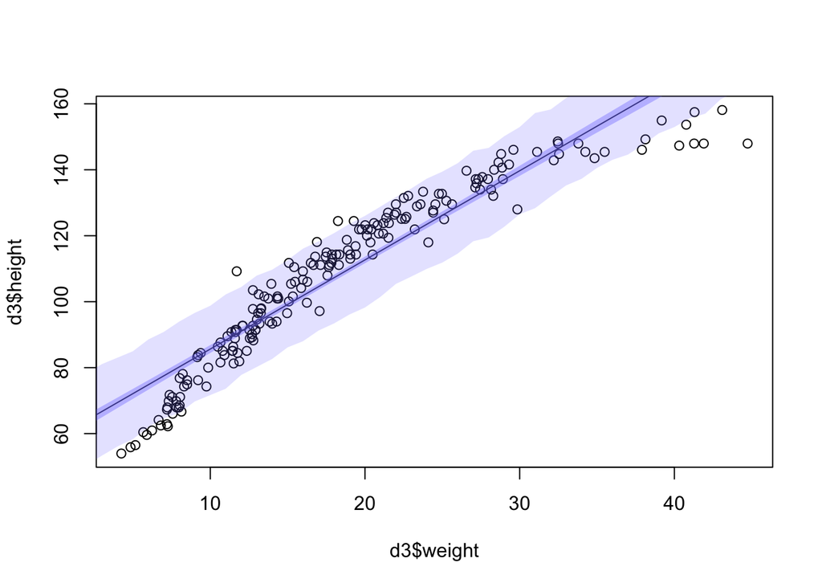

```r
d3.samples = link(d3.model, data = data.frame(weight=seq(0, 45)))
d3.sim = sim(d3.model, data = data.frame(weight=seq(0, 45)))
d3.mu = apply(d3.samples, 2, mean)
d3.PI = apply(d3.samples, 2, PI, prob=0.89)
d3.sim.PI = apply(d3.sim, 2, PI, prob=0.89)

plot(d3$weight, d3$height)
lines(seq(0, 45), d3.mu)
shade(d3.PI, seq(0, 45), col=col.alpha(rangi2, 0.4))
shade(d3.sim.PI, seq(0, 45), col=col.alpha(rangi2, 0.2))
```

It’s kind of weird to me that the confidence interval for the mean is so sharp, the predictive interval looks okay.

Still, it’s clearly not a linear fit so it so it would be good if the line did curve a little bit.

## 4h3

Suppose a colleague of yours, who works on allometry, glances at the practice problems just above. Your colleague exclaims, “That’s silly. Everyone knows that it’s only the logarithm of body weight that scales with height!” Let’s take your colleague’s advice and see what happens.

1. Model the relationship between height (cm) and the natural logarithm of weight (log-kg). Use the entire Howell1 data frame, all 544 rows, adults and non-adults. Can you interpret the resulting estimates?
2. Begin with this plot: plot( height ~ weight, data=Howell1). Then use samples from the quadratic approximate posterior of the model in (a) to superimpose on the plot: 1. the predicted mean height as a function of weight 2. the 97% interval for the mean 3. the 97% interval for predicted heights

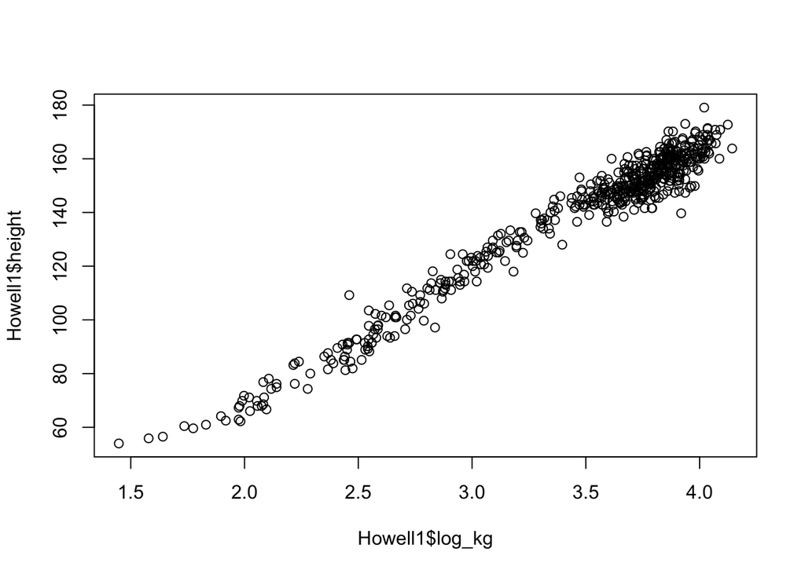

```r
Howell1$log_kg = log(Howell1$weight)

plot(Howell1$log_kg, Howell1$height)
```

```r
log_kg.bar = mean(Howell1$log_kg)

Howell1.model = quap(
  alist(
    height ~ dnorm(mu, sigma),
    mu <- a + b*(log_kg - log_kg.bar),
    a ~ dnorm(120, 5),
    b ~ dnorm(10, 10),
    sigma ~ dexp(0.01)
  ),
  Howell1
)

precis(Howell1.model)
```

```
##             mean        sd       5.5%      94.5%
## a     138.228258 0.2199450 137.876744 138.579773
## b      47.032010 0.3823137  46.420999  47.643022
## sigma   5.134681 0.1556699   4.885891   5.383472
```

The important thing to realise now is that the coefficients are expressed in terms of log-weight and not weight itself.

So then the height of someone of average log weight is 138.23 and they gain/lose roughly 50cm for each unique of log-weight.

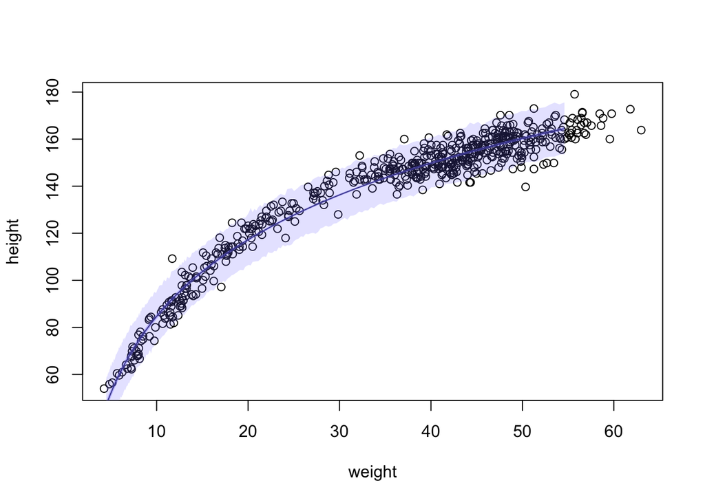

```r
Howell1.samples = link(Howell1.model, data = data.frame(log_kg=seq(1.5, 4, 0.01)))
Howell1.sim = sim(Howell1.model, data = data.frame(log_kg=seq(1.5, 4, 0.01)))
Howell1.mu = apply(Howell1.samples, 2, mean)
Howell1.PI = apply(Howell1.samples, 2, PI, prob=0.97)
Howell1.sim.PI = apply(Howell1.sim, 2, PI, prob=0.97)

plot( height ~ weight, data=Howell1)
lines(exp(seq(1.5, 4, 0.01)), Howell1.mu)
shade(Howell1.PI, exp(seq(1.5, 4, 0.01)), col=col.alpha(rangi2, 0.4))
shade(Howell1.sim.PI, exp(seq(1.5, 4, 0.01)), col=col.alpha(rangi2, 0.2))
```

Wow that’s pretty impressive that the mean is so sharp, it’s a great fit for the data!

The rest of the questions don’t seem that interesting and I’m tired so I’m going to skip them for now. I may come back to them at another time.